# EDA

## 1. Importing the libraries.

Before going ahead & performing Exploratory Data Analysis (EDA), let us import the essential libraries first. Remember that 'matplotlib' & 'seaborn' are the libraries used to perform EDA and generate visualizations on data.

```python
import pandas as pd
import numpy as np
import matplotlib.pyplot as plt
import seaborn as sns
```

## 2. Reading the data.

Let us read the dataset now.

```python
tips_data = pd.read_csv("tips.csv")
```

```python
tips_data
```

|  | total_bill | tip | sex | smoker | day | time | size | price_per_person | Payer Name | CC Number | Payment ID |
| --- | --- | --- | --- | --- | --- | --- | --- | --- | --- | --- | --- |
| 0 | 16.99 | 1.01 | Female | No | Sun | Dinner | 2 | 8.49 | Christy Cunningham | 3560325168603410 | Sun2959 |
| 1 | 10.34 | 1.66 | Male | No | Sun | Dinner | 3 | 3.45 | Douglas Tucker | 4478071379779230 | Sun4608 |
| 2 | 21.01 | 3.50 | Male | No | Sun | Dinner | 3 | 7.00 | Travis Walters | 6011812112971322 | Sun4458 |
| 3 | 23.68 | 3.31 | Male | No | Sun | Dinner | 2 | 11.84 | Nathaniel Harris | 4676137647685994 | Sun5260 |
| 4 | 24.59 | 3.61 | Female | No | Sun | Dinner | 4 | 6.15 | Tonya Carter | 4832732618637221 | Sun2251 |
| ... | ... | ... | ... | ... | ... | ... | ... | ... | ... | ... | ... |
| 239 | 29.03 | 5.92 | Male | No | Sat | Dinner | 3 | 9.68 | Michael Avila | 5296068606052842 | Sat2657 |
| 240 | 27.18 | 2.00 | Female | Yes | Sat | Dinner | 2 | 13.59 | Monica Sanders | 3506806155565404 | Sat1766 |
| 241 | 22.67 | 2.00 | Male | Yes | Sat | Dinner | 2 | 11.34 | Keith Wong | 6011891618747196 | Sat3880 |
| 242 | 17.82 | 1.75 | Male | No | Sat | Dinner | 2 | 8.91 | Dennis Dixon | 4375220550950 | Sat17 |
| 243 | 18.78 | 3.00 | Female | No | Thur | Dinner | 2 | 9.39 | Michelle Hardin | 3511451626698139 | Thur672 |

244 rows × 11 columns

```python
tips_data.head()
```

|  | total_bill | tip | sex | smoker | day | time | size | price_per_person | Payer Name | CC Number | Payment ID |
| --- | --- | --- | --- | --- | --- | --- | --- | --- | --- | --- | --- |
| 0 | 16.99 | 1.01 | Female | No | Sun | Dinner | 2 | 8.49 | Christy Cunningham | 3560325168603410 | Sun2959 |
| 1 | 10.34 | 1.66 | Male | No | Sun | Dinner | 3 | 3.45 | Douglas Tucker | 4478071379779230 | Sun4608 |
| 2 | 21.01 | 3.50 | Male | No | Sun | Dinner | 3 | 7.00 | Travis Walters | 6011812112971322 | Sun4458 |
| 3 | 23.68 | 3.31 | Male | No | Sun | Dinner | 2 | 11.84 | Nathaniel Harris | 4676137647685994 | Sun5260 |
| 4 | 24.59 | 3.61 | Female | No | Sun | Dinner | 4 | 6.15 | Tonya Carter | 4832732618637221 | Sun2251 |

## 3. Exploratory Data Analysis (EDA)

### 3.1 Plotting a simple line chart

Let us perform Exploratory Data Anaylsis (EDA). EDA in Machine Learning refers to generating visualizations and insights from the data.

We will start with matplotlib & see how the visualizations look like. Let us define the input co-ordinates 'a' & 'b' as a list of elements.

```python
# Defining the co-ordinates
a = [2,3,4,5,6]
b = [10,20,30,40,100]
```

To generate a plot using 'matplotib' we use the command 'plt.plot' followed by the co-ordinates on X & Y axis. The syntax would be: **plt.plot(Co-ordinate_variable_of_X_axis,Co-ordinate_variable_of_Y_axis)**

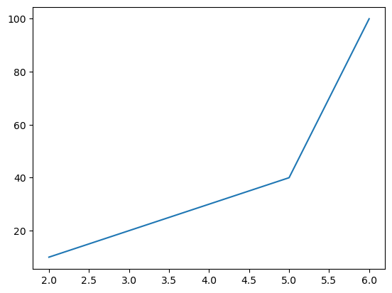

```python
plt.plot(a,b)
```

The above graph is a line graph generated using matplotlib, let us add some extra elements now.

To add labels to X & Y-axis, we use the command 'plt.xlabel/plt.ylabel'.

For X_axis the syntax would be: **plt.xlabel('label_name')**

For Y_axis the syntax would be: **plt.ylabel('label_name')**

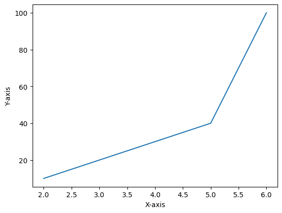

```python
# Assigning a lables to the visualisation

plt.plot(a,b)
plt.xlabel("X-axis")
plt.ylabel("Y-axis")
```

Now that we have added label to the plot, let us add the graph title as well.

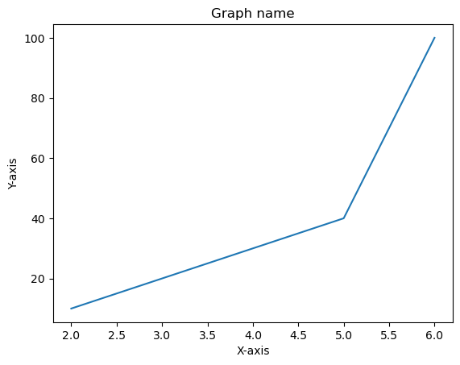

```python
# Assigning a title to the visualisation

plt.plot(a,b)
plt.xlabel("X-axis")
plt.ylabel("Y-axis")
plt.title("Graph name")
```

### 3.2 Dropping a column in Python

To drop a column in Python, we use the command:

**data_name.drop(columns=['column_1','column_2',......'column_n'], inplace = True)**

inplace= True is a command that updates the changes in the dataset in place itself.

Let us drop some columns from the 'tips_data' dataset.

```python
tips_data.drop(columns= ["Payer Name","CC Number","Payment ID","price_per_person"], inplace=True)
```

```python
tips_data
```

|  | total_bill | tip | sex | smoker | day | time | size |
| --- | --- | --- | --- | --- | --- | --- | --- |
| 0 | 16.99 | 1.01 | Female | No | Sun | Dinner | 2 |
| 1 | 10.34 | 1.66 | Male | No | Sun | Dinner | 3 |
| 2 | 21.01 | 3.50 | Male | No | Sun | Dinner | 3 |
| 3 | 23.68 | 3.31 | Male | No | Sun | Dinner | 2 |
| 4 | 24.59 | 3.61 | Female | No | Sun | Dinner | 4 |
| ... | ... | ... | ... | ... | ... | ... | ... |
| 239 | 29.03 | 5.92 | Male | No | Sat | Dinner | 3 |
| 240 | 27.18 | 2.00 | Female | Yes | Sat | Dinner | 2 |
| 241 | 22.67 | 2.00 | Male | Yes | Sat | Dinner | 2 |
| 242 | 17.82 | 1.75 | Male | No | Sat | Dinner | 2 |
| 243 | 18.78 | 3.00 | Female | No | Thur | Dinner | 2 |

244 rows × 7 columns

### 3.3 Example: Plot the bar graph of Day vs Total bill list

Let us look at one example now to understand EDA better. Let us plot of Day vs Total bill list.

To perform this, first let us separate column data from the dataset into different variables.

For instance, I have split 'totaL_bill' column data from 'tips_data' into variable 'total_bill_list'

& I have split 'day' column data from 'tips_data' into variable 'day'.

```python
total_bill_list= tips_data["total_bill"]
day =  tips_data["day"]
```

To plot a bar graph, we use the command: **plt.bar(Co-ordinate_variable_of_X-axis,Co-ordinate_variable_of_Y-axis)**

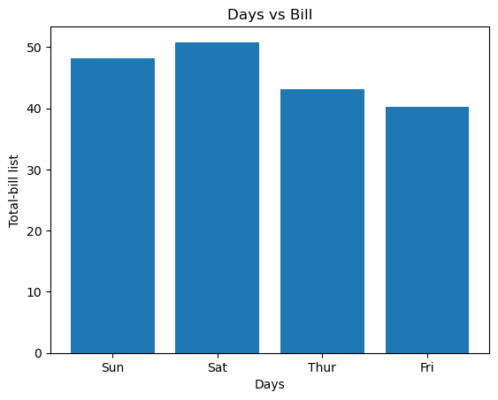

```python
plt.bar(day,total_bill_list)
plt.xlabel("Days")
plt.ylabel("Total-bill list")
plt.title("Days vs Bill")
```

### 3.4 Example: Do more people visit for Dinner or Lunch

Let us do EDA to analyze whether more people visit for Dinner or Lunch.

Before that let us understand the problem first. The problem here is to find whether more people visit for Dinner or Lunch. In other words, one has to find the frequency of time spend by people on Dinner & Lunch.

In 'tips_data' we have a column 'time' which has 'Dinner' & 'Lunch' as values. Let us first count the total values for time column using the command below.

```python
# Counting the total values in time column
# value_counts() returns the count of the column

Time= tips_data["time"].value_counts()  # Storing the count and not the continous value of time.
```

```python
Time
```

```
time
Dinner    176
Lunch      68
Name: count, dtype: int64
```

value_counts() function returns the total value count for a specified column. The proper sytanx would be:

**data_name["Column_name"].value_counts()**

Now let us use seaborn to visualize data, we have used alias as 'sns' to define Seaborn library.

To plot a bar graph using seaborn we use the command: **sns.barplot(x = value_on_X_axis, y = value_on_Y_axis)**

'.index' is used to return the labels whereas '.values' returns the values of the index specified.

In the command below, we are using 'Dinner & Label' as Index on X-axis and we plot their corresponding values on Y-axis.

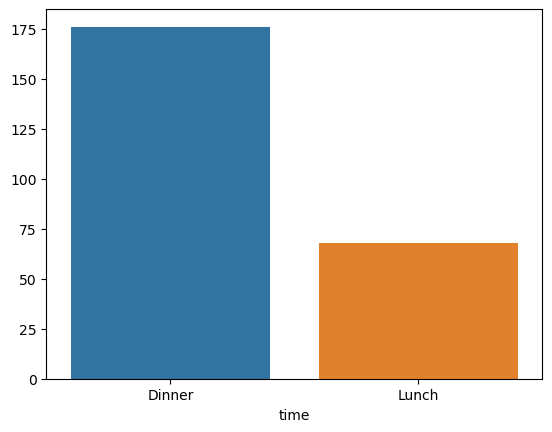

```python
# Plotting the graph for total count of Time in distribution of Dinner and Lunch

sns.barplot(x = Time.index, y= Time.values)  # Here Index is "Dinner" & "Lunch" & value is the count
```

However, the frequency will get influenced by the size (number) of people visiting the restaurant. So, to consider the 'size' column as well, we need to group 'time' with respect to 'size'.

So let us Group the column 'size' with respect to 'Time'.

Grouped column will be in square bracket, while the column w.r.t it is getting grouped is in curved bracket.

Syntax is then followed by the measure of aggregation ('Sum' in this case) and reset index just to clear the index back to zero.

The syntax would be: **dataset_name.groupby("grouped_column")["column_wrt_to_its_getting_grouped"].sum().reset_index()**

```python
size = tips_data.groupby("time")["size"].sum().reset_index()
```

Let us plot a seaborn bar plot of time vs size.

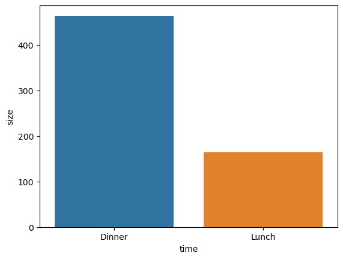

```python
sns.barplot(x = "time", y= "size",data = size)
```

Let us put the axis labels & title.

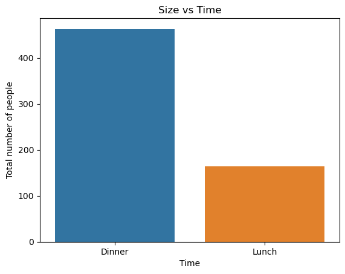

```python
sns.barplot(x = "time", y= "size",data = size)
plt.xlabel("Time")
plt.ylabel("Total number of people")
plt.title("Size vs Time")
```